# Predict race/ethnicity based on census data

## Setups

```r
if (!requireNamespace('wru')) install.packages('wru')

library(wru)
library(tidyverse)
library(lubridate)
source('utils/r-utils.R')

theme_set(theme_bw() + theme(legend.title = element_blank()))
```

## Load data

and use the `wru` package to predict race based on last_names only

```r
pubmed_race_df <- read_tsv('data/pubmed/authors.tsv.xz') %>%
  filter(reverse_position == 1) %>%
  left_join(read_tsv('data/pubmed/articles.tsv.xz'), by = 'pmid') %>%
  mutate(year = substr(publication_date, 1, 4) %>% ymd(truncated = 2),
         publication_date = ymd(publication_date, truncated = 2)) %>%
  rename('surname' = last_name) %>%
  predict_race(surname.only = T, impute.missing = F)
```

```
## [1] "Proceeding with surname-only predictions..."
```

```r
iscb_race_df <- read_tsv('data/iscb/keynotes.tsv') %>%
  rename('surname' = last_name) %>%
  mutate(year = ymd(year, truncated = 2)) %>%
  predict_race(surname.only = T, impute.missing = F)
```

```
## [1] "Proceeding with surname-only predictions..."
```

```r
# 10 random unmatched names
iscb_race_df %>%
  filter(is.na(pred.whi)) %>%
  select(1,2) %>%
  sample_n(10)
```

```
##          year                   full_name
## 1  2000-01-01                Hans Lehrach
## 2  2010-01-01                Svante Paabo
## 3  2015-01-01               Rolf Apweiler
## 4  2010-01-01                Isaac Kohane
## 5  2012-01-01           Gunnar von Heijne
## 6  1999-01-01               Cyrus Chothia
## 7  2003-01-01 Christiane Nüsslein-Volhard
## 8  2017-01-01                Laxmi Parida
## 9  2015-01-01                Amos Bairoch
## 10 2019-01-01            Franziska Michor
```

```r
alpha <- qnorm(0.975)
start_year <- 1997
end_year <- 2020
n_years <- end_year - start_year
my_jours <- unique(pubmed_race_df$journal)
my_confs <- unique(iscb_race_df$conference)
n_jours <- length(my_jours)
n_confs <- length(my_confs)
race_levels <- c('White', 'Asian', 'Black', 'Hispanic', 'Others', 'All others')
```

Pubmed authors: 7891 last_names out of 29615 were not matched. iscb: 82 surnames out of 348 were not matched.

## Prepare data frames for later analyses:

- bind_rows results of race predictions in iscb and Pubmed authors
- pivot long
- compute mean, sd, marginal error
- add “White” vs. “Others”
- separate by journals
- separate by conference keynote speakers/fellows

```r
iscb_pubmed <- iscb_race_df %>%
  rename('journal' = conference) %>%
  select(year, journal, contains('pred')) %>%
  mutate(publication_date = year,
         type = 'Keynote speakers/Fellows') %>%
  bind_rows(
    pubmed_race_df %>%
      select(year, journal, contains('pred'), publication_date) %>%
      mutate(type = 'Pubmed authors')
  ) %>%
  mutate(pred_sum_others = pred.his + pred.oth + pred.bla) %>%
  pivot_longer(contains('pred'),
               names_to = 'Race',
               values_to = 'probabilities') %>%
  recode_race() %>%
  group_by(type, year, publication_date, Race) %>%
  add_count() %>%
  mutate(
    mean_prob = mean(probabilities, na.rm = T),
    sd_prob = sd(probabilities, na.rm = T),
    n = mean(n),
    me_prob = alpha * sd_prob / sqrt(n)
  ) %>%
  ungroup()
```

### By journals

```r
pubmed_race <- vector('list', length = n_jours)
i <- 0

for (jour in my_jours){
  i <- i + 1
  pubmed_race[[i]] <- iscb_pubmed %>%
    filter(type == 'Pubmed authors' & journal == jour & (Race != 'All others')) %>%
    group_by(year, Race, journal) %>%
    summarise(mean_prob = mean(probabilities, na.rm = T)) %>%
    ungroup()
}
```

### By conference keynote speakers/fellows

```r
iscb_race <- vector('list', length = n_confs)
i <- 0

for (conf in my_confs){
  i <- i + 1
  iscb_race[[i]] <- iscb_pubmed %>%
    filter(type != 'Pubmed authors' & journal == conf & (Race != 'All others')) %>%
    group_by(year, Race, journal) %>%
    summarise(mean_prob = mean(probabilities, na.rm = T)) %>%
    ungroup()
}
```

## Comparisons

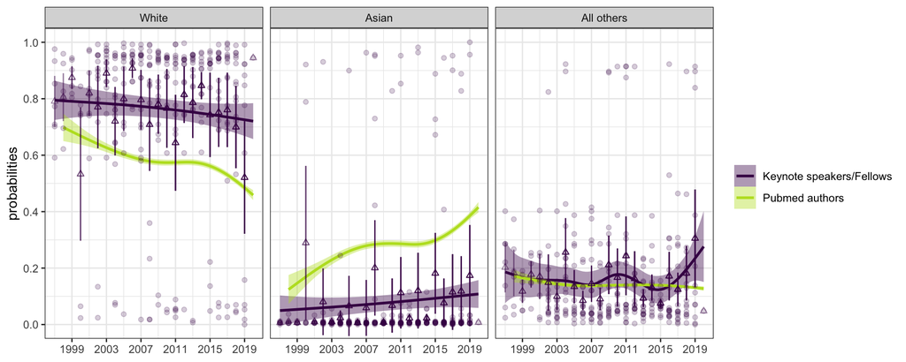

```r
ggplot(iscb_pubmed %>% filter(Race == 'White' | Race == 'Asian' | Race == 'All others'),
       aes(x = year)) +
  facet_grid(cols = vars(fct_rev(Race))) +
  geom_smooth(aes(x = publication_date, y = probabilities, color = type, fill = type)) +
  geom_point(
    data = . %>% filter(type != 'Pubmed authors'),
    aes(y = probabilities, color = type),
    alpha = 0.2,
    show.legend = F
  ) +
  geom_point(
    data = . %>% get_summary(),
    aes(y = mean_prob, color = type),
    shape = 2,
    alpha = 0.5,
    show.legend = F
  ) +
  geom_linerange(
    data = . %>% get_summary(),
    aes(
      ymin = mean_prob - me_prob,
      ymax = mean_prob + me_prob,
      color = type
    ),
    alpha = 0.5,
    show.legend = F
  ) +
  scale_y_continuous(breaks = seq(0, 1, 0.2)) +
  scale_x_date(breaks = '4 years', labels = scales::date_format("%Y")) +
  scale_color_viridis_d(option = 'D', end = 0.9) +
  scale_fill_viridis_d(option = 'D', end = 0.9) +
  coord_cartesian(ylim = c(0, 1)) +
  labs(x = NULL)
```

A simpler figure, supplementary Fig S2?

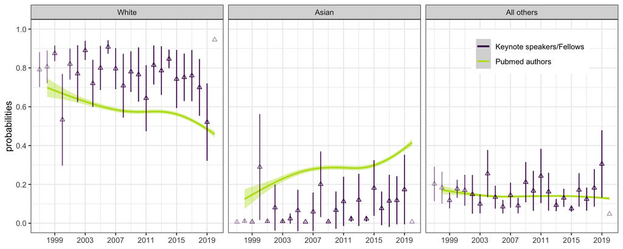

```r
ggplot(iscb_pubmed %>% filter(Race == 'White' | Race == 'Asian' | Race == 'All others'),
       aes(x = year, color = type, fill = type)) +
  facet_grid(cols = vars(fct_rev(Race))) +
  geom_smooth(data = . %>% filter(type == 'Pubmed authors'),
              aes(x = publication_date, y = probabilities)) +
  geom_point(
    data = . %>% get_summary(),
    aes(y = mean_prob),
    shape = 2,
    alpha = 0.5,
    show.legend = F
  ) +
  geom_linerange(
    data = . %>% get_summary(),
    aes(
      ymin = mean_prob - me_prob,
      ymax = mean_prob + me_prob
    ),
    alpha = 0.5,
    show.legend = F
  ) +
  guides(fill = F) +
  scale_y_continuous(breaks = seq(0, 1, 0.2)) +
  scale_x_date(breaks = '4 years', labels = scales::date_format("%Y")) +
  scale_color_viridis_d(option = 'D', end = 0.9) +
  scale_fill_viridis_d(option = 'D', end = 0.9) +
  coord_cartesian(ylim = c(0, 1)) +
  labs(x = NULL) +
  theme(legend.position = c(0.85, 0.85))
```

Here, each circle is a name mention. The vertical intervals are confidence intervals of the mean probability of selecting a race/ethnicity category in the US census (triangle).

```r
# Check: probabilities, if valid, should add up to 1
iscb_pubmed %>%
  filter(Race == 'White' | Race == 'Asian' | Race == 'All others') %>%
  group_by(type, year, publication_date, Race) %>%
  summarise(mean_prob = mean(probabilities, na.rm = T)) %>%
  summarise(all_prob = sum(mean_prob))
```

```
## # A tibble: 4,505 x 4
## # Groups:   type, year [47]
##    type                     year       publication_date all_prob
##    <chr>                    <date>     <date>              <dbl>
##  1 Keynote speakers/Fellows 1997-01-01 1997-01-01              1
##  2 Keynote speakers/Fellows 1998-01-01 1998-01-01              1
##  3 Keynote speakers/Fellows 1999-01-01 1999-01-01              1
##  4 Keynote speakers/Fellows 2000-01-01 2000-01-01              1
##  5 Keynote speakers/Fellows 2001-01-01 2001-01-01              1
##  6 Keynote speakers/Fellows 2002-01-01 2002-01-01              1
##  7 Keynote speakers/Fellows 2003-01-01 2003-01-01              1
##  8 Keynote speakers/Fellows 2004-01-01 2004-01-01              1
##  9 Keynote speakers/Fellows 2005-01-01 2005-01-01              1
## 10 Keynote speakers/Fellows 2006-01-01 2006-01-01              1
## # … with 4,495 more rows
```

## Figures for paper

### All fellows and keynotes compared to last authors in ISCB partner journals:

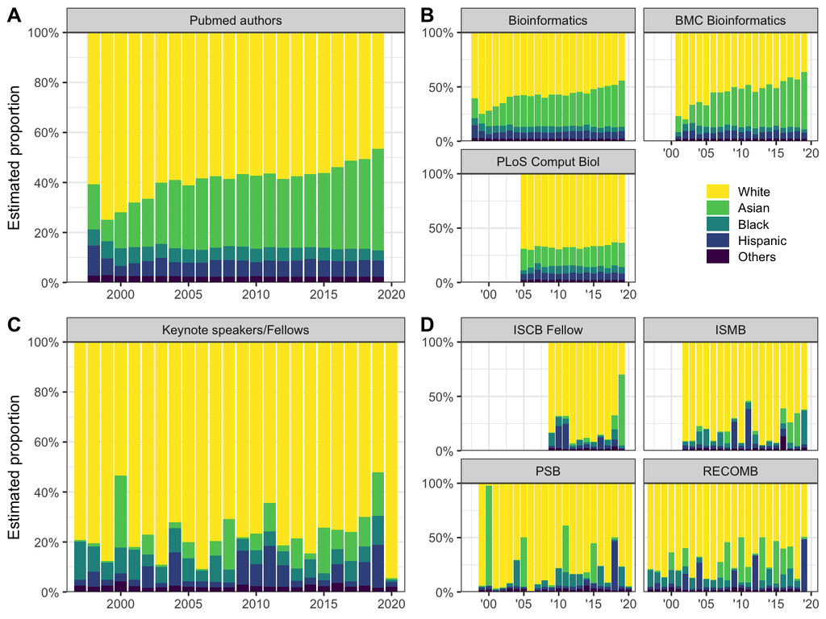

```r
fig_2a <- iscb_pubmed %>%
  filter(Race != 'All others',
         type == 'Pubmed authors') %>%
  group_by(year, type, Race) %>%
  summarise(mean_prob = mean(probabilities, na.rm = T)) %>%
  ungroup() %>%
  race_breakdown(category = 'main', type)

fig_2c <- iscb_pubmed %>%
  filter(Race != 'All others',
         type != 'Pubmed authors') %>%
  group_by(year, type, Race) %>%
  summarise(mean_prob = mean(probabilities, na.rm = T)) %>%
  ungroup() %>%
  race_breakdown(category = 'main', type)

fig_2b <- bind_rows(pubmed_race) %>%
  race_breakdown(category = 'sub', journal) +
  theme(legend.position = c(0.8, 0.25),
        legend.key.height = unit(4, 'mm'),
        legend.background = element_rect(fill = "transparent", colour = "transparent"))

fig_2d <- bind_rows(iscb_race) %>%
  race_breakdown(category = 'sub', journal)

fig_2 <- cowplot::plot_grid(fig_2a, fig_2b, fig_2c, fig_2d, labels = 'AUTO')

fig_2
```

```r
ggsave('figs/racial_makeup.png', fig_2, width = 7, height = 5)
```

All Asian speakers at PSB 2000?

```r
iscb_race_df %>% filter(year == '2000-01-01', conference == 'PSB')
```

```
##         year full_name fore_name surname conference source pred.whi
## 1 2000-01-01  Wah Chiu       Wah    Chiu        PSB   <NA>   0.0233
##   pred.bla pred.his pred.asi pred.oth
## 1  0.00055   0.0317   0.9211  0.02335
```

PSB only had one keynote speaker in 2000, Wah Chiu.

What’s in Bioinformatics 1999?

```r
pubmed_race_df %>%
  filter(year == '1999-01-01' & !is.na(pred.whi)) %>%
  select(contains('pred')) %>%
  colMeans()
```

```
##   pred.whi   pred.bla   pred.his   pred.asi   pred.oth
## 0.74829564 0.06930611 0.06557128 0.08713391 0.02969306
```

```r
pubmed_race_df %>%
  filter(year == '1999-01-01' & !is.na(pred.whi)) %>%
  filter(pred.asi > 0.1) %>%
  select(fore_name, surname, pred.asi)
```

```
##    fore_name surname  pred.asi
## 1          O    Poch 0.1342000
## 2          M   Afzal 0.8004200
## 3        H J     Kim 0.9446055
## 4        K M    Chao 0.8670867
## 5        A K  Bansal 0.9475000
## 6          K   Nakai 0.3584642
## 7        A S   Reddy 0.6612000
## 8          A    Sali 0.1155000
## 9        A E   Torda 0.2910291
## 10         L   Zhang 0.9806000
```

```r
pubmed_race_df %>%
  filter(year == '1999-01-01' & !is.na(pred.whi)) %>%
  filter(pred.his > 0.1) %>%
  select(fore_name, surname, pred.his)
```

```
##   fore_name        surname  pred.his
## 1         P Rodriguez-Tomé 0.9377938
## 2         R          Rozas 0.3190000
## 3       J J           Rosa 0.6495350
## 4       M P        Lefranc 0.2014000
## 5         A       Valencia 0.8923000
## 6       A E          Torda 0.1005101
```